# Registered Report

Marqus Odisho

2024-11-29

## Proposed Analysis Pipeline:

### Preprocessing Steps:

There will be separate simulations for two different cases of assortative mating. In both cases, the initial maternal and paternal q scores will be simulated following a beta distribution. A beta distribution is ideal for q scores as they can take on values between 0 and 1. The initial pattern for the beta distribution of q scores will be a bimodal pattern with peaks around 0 and 1 indicating that a majority of the individuals are parental species rather than hybrids. 1000 maternal and paternal q scores will be simulated for a total of 2000 which is consistent with literature on the topic of assortative mating simulation. Using the sample function in R, maternal q scores will be sampled from the initial maternal q score dataset before being matched with sampled paternal q scores. In the strict case of assortative mating, maternal q scores will be paired with paternal q scores of a similar value. In the case of mating based on extreme phenotype, the maternal q scores will be paired with paternal q scores with extreme values (e.g. maternal q scores less than 0.5 will be paired with paternal q scores closer to 0 and maternal q scores higher than 0.5 will be paired with paternal q scores closer to 1). Using these pairings for both assortative mating types, the parental q scores will be averaged to generate offspring q scores. No statistical power analysis is proposed as the thesis involves the simulation of data rather than sampling associated with laboratory and fieldwork methodology.

It is important to note that the aforementioned steps are done to approximate a dataset that would otherwise be simulated using forward genetic simulation software. This requires simplifying assumptions such as blended inheritance for offspring, matching based on q scores, and the exclusion of phenotypes.

### Planned Analysis:

#### Spearman’s rank correlation test:

This test assesses the correlation between the paired maternal and paternal q scores. This non-parametric correlation test will be performed instead of Pearson’s correlation test as q scores are not normally distributed. In both cases of assortative mating, a correlation is expected, with the null hypothesis being random mating. A positive correlation would indicate a preference for mates with a similar q score.

#### Beta regression:

A beta regression will be used as the response variable (q score) follows a beta distribution. Potential parameters to explore include hybridization rates, strength of preference, and the influence of mating pool availability on preference.

It should be noted that due to the simplifying assumptions made in this code, a beta regression was not performed. Furthermore, strength of preference was preset for both cases of assortative mating based on sampling and matching probabilities for q scores.

### Code Description:

The code simulates assortative mating between two species to potentially form hybrid offspring. This assortative mating will be based on q scores which can range from 0 (which indicates species 1) to 1 (which indicates species 2) and intermediate values which indicate hybrids of the two. The code will simulate two types of assortative mating, the strict definition which means that individuals will want to mate with someone with an identical q score and the extreme phenotype definition which is where individuals will want to mate with someone with either a higher or lower q score than them. The code will simulate individual maternal and paternal datasets and then pair them up based on either of the two assortative mating definitions previously mentioned. The aforementioned pairing will be visualized in a scatter plot to show the mating patterns. Then, offspring will be generated based on those previous mating patterns that will be a blend of the q scores of both parents. The q scores of the offspring will be plotted to show how different assortative mating patterns influence hybrid zone outcomes. A correlation test will be performed on the data to understand the relationship between the q scores.

### Assortative Mating - Strict Definition

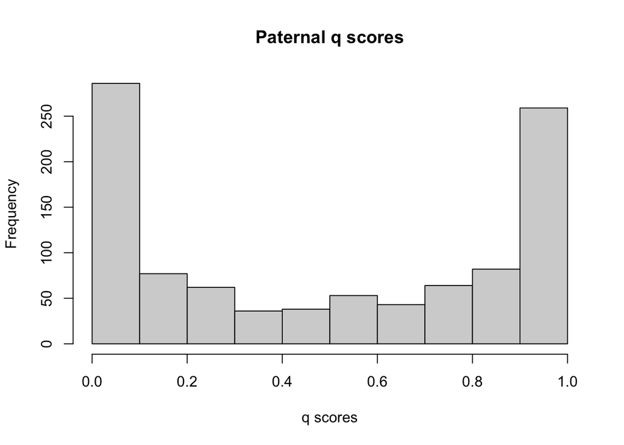

```r
# Create two datasets, q_maternal and q_paternal, each with 1000 data points following a beta distribution where the most common q scores are 1 or 0 but there are hybrids
q_maternal <- rbeta(1000, 0.3, 0.3)
q_paternal <- rbeta(1000, 0.3, 0.3)

# Display simulated dataset distributions before sampling
hist(q_paternal,
     main = "Paternal q scores",
     xlab = "q scores"
     )
```

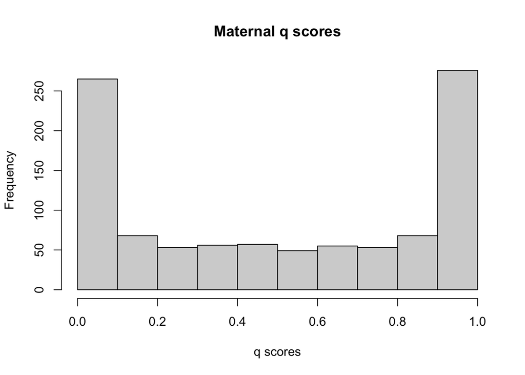

```r
hist(q_maternal,
     main = "Maternal q scores",
     xlab = "q scores"
     )
```

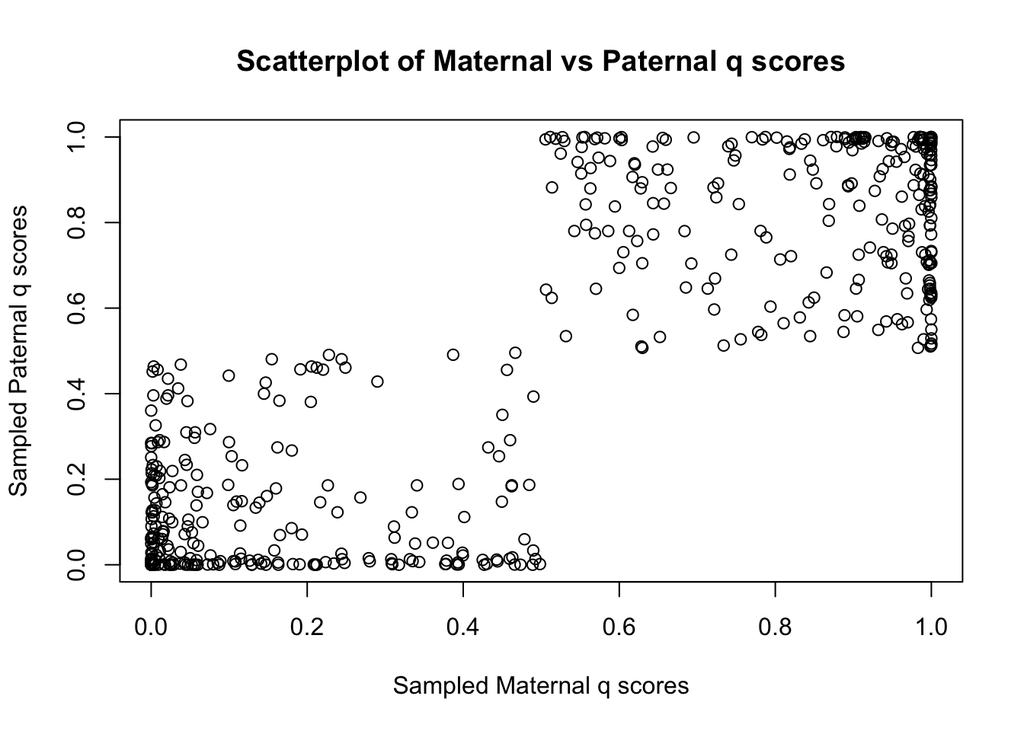

```r
# Create a new dataset, sampled_q_maternal, by sampling 500 q scores without replacement from the q_maternal dataset
sampled_q_maternal <- sample(q_maternal, 500, replace = FALSE)

# Create a new variable, sampled_q_paternal, by sampling 500 q scores from the q_paternal dataset
# Use the ifelse() function to set the probability of selecting a q score from q_paternal based on the corresponding q score in sampled_q_maternal, in this case the function x represents sampled maternal q scores that are then being matched with sampled paternal q scores based on preset probabilities.
sampled_q_paternal <- sapply(sampled_q_maternal, function(x) {
  if (x >= 0.5) {
    sample(q_paternal[q_paternal >= 0.5], 1, prob = rep(0.9 / length(q_paternal[q_paternal >= 0.5]), length(q_paternal[q_paternal >= 0.5])))
  } else {
    sample(q_paternal[q_paternal < 0.5], 1, prob = rep(0.1 / length(q_paternal[q_paternal < 0.5]), length(q_paternal[q_paternal < 0.5])))
  }
})

# Create a new dataframe, q_scores_df, by combining sampled_q_maternal and sampled_q_paternal
q_scores_df <- data.frame(sampled_q_maternal, sampled_q_paternal)

# Plot a scatterplot of sampled_q_paternal versus sampled_q_maternal to visualize the relationship between the two variables where mating is based on having a similar q score
plot(sampled_q_maternal, sampled_q_paternal, xlab="Sampled Maternal q scores", ylab="Sampled Paternal q scores", main="Scatterplot of Maternal vs Paternal q scores")
```

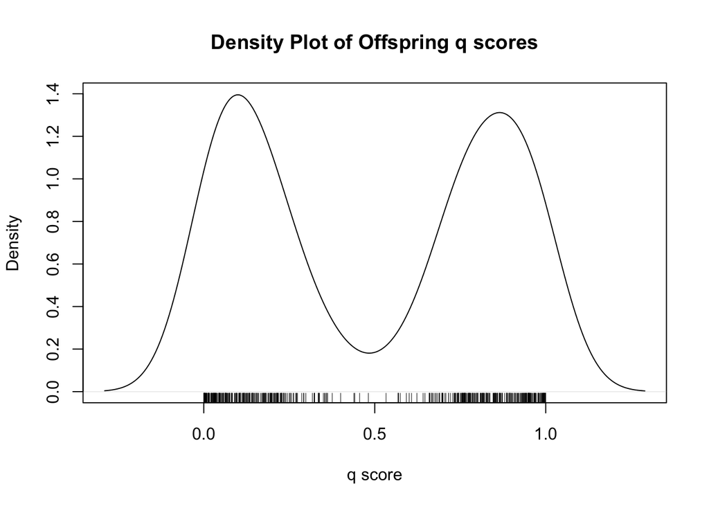

```r
# To plot offspring q scores, take the q scores of the parents from the previous data frame and average them
q_scores_df$averaged_q_scores <- (q_scores_df$sampled_q_maternal + q_scores_df$sampled_q_paternal) / 2


# Plot the density plot which shows offspring q scores based on the strict definition of assortative mating
plot(density(q_scores_df$averaged_q_scores),
     main = "Density Plot of Offspring q scores",
     xlab = "q score",
     ylab = "Density")

# Add a rug plot to the bottom of the density plot to show the individual data points that make up the distribution
rug(q_scores_df$averaged_q_scores)
```

```r
# Perform Spearman rank correlation test between maternal and paternal q scores
cor_test_result <- cor.test(q_scores_df$sampled_q_maternal,
                           q_scores_df$sampled_q_paternal,
                           method = "spearman")
# Print the correlation test result
print(cor_test_result)
```

```
##
##  Spearman's rank correlation rho
##
## data:  q_scores_df$sampled_q_maternal and q_scores_df$sampled_q_paternal
## S = 5442613, p-value < 2.2e-16
## alternative hypothesis: true rho is not equal to 0
## sample estimates:
##       rho
## 0.7387536
```

### Assortative Mating - Extreme Phenotype Preference

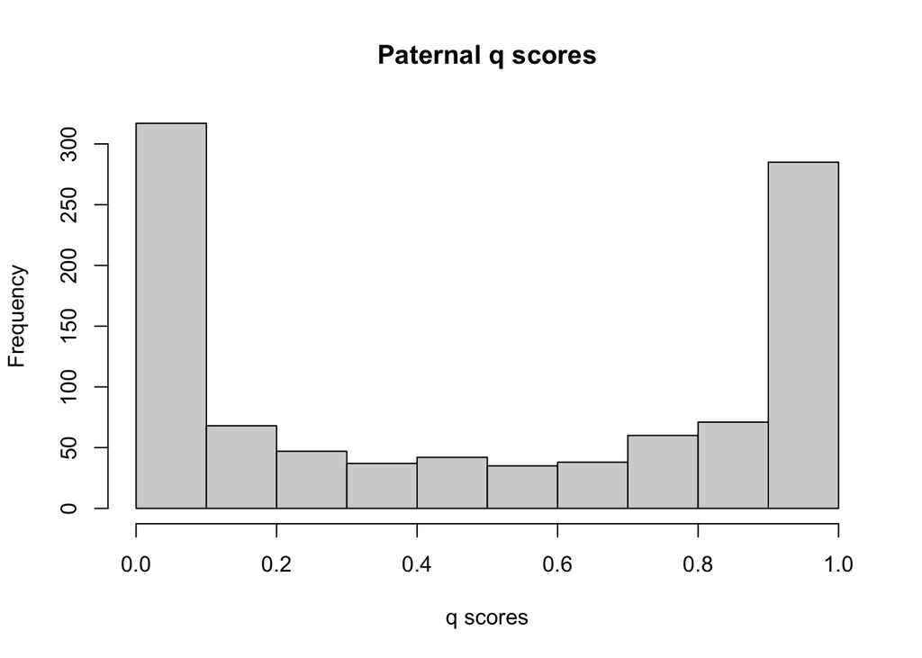

```r
# Create two datasets, q_maternal and q_paternal, each with 1000 data points following a beta distribution
q_maternal <- rbeta(1000, 0.3, 0.3)
q_paternal <- rbeta(1000, 0.3, 0.3)

# Display simulated dataset distribution before sampling
hist(q_paternal,
     main = "Paternal q scores",
     xlab = "q scores"
     )
```

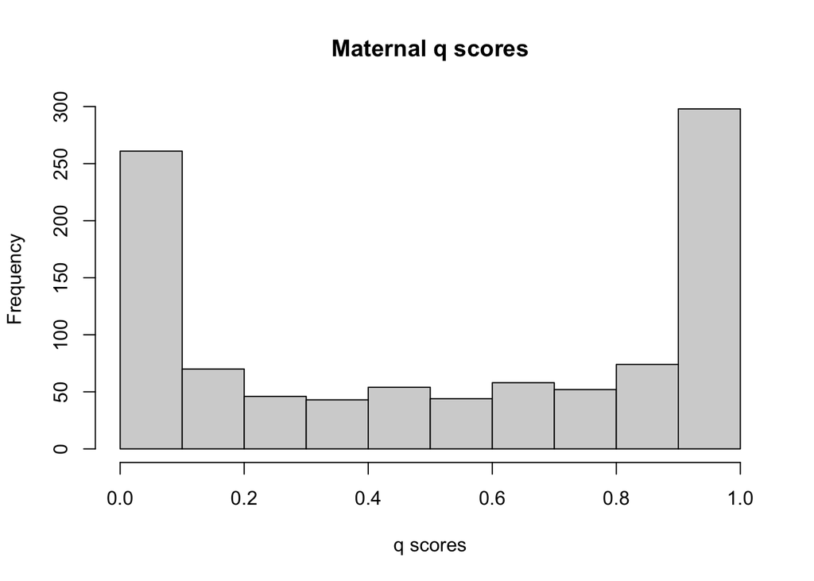

```r
hist(q_maternal,
     main = "Maternal q scores",
     xlab = "q scores"
     )
```

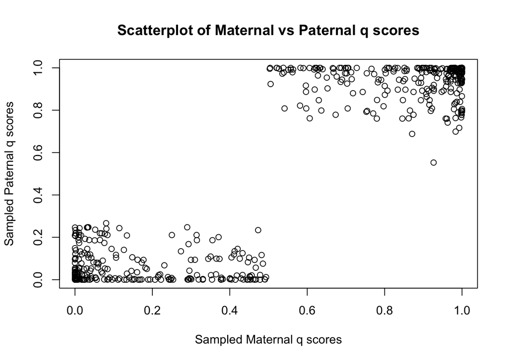

```r
# Create a new dataset, sampled_q_maternal, by sampling 500 q scores without replacement from the q_maternal dataset
sampled_q_maternal <- sample(q_maternal, 500, replace = FALSE)

# Create a new variable, sampled_q_paternal, by sampling 500 q scores from the q_paternal dataset
# Use the ifelse() function to set the probability of selecting a q score from q_paternal based on the corresponding q score in sampled_q_maternal, in this case the function x represents sampled maternal q scores that are then being matched with sampled paternal q scores based on preset probabilities.
sampled_q_paternal <- sapply(sampled_q_maternal, function(x) {
  if (x <= 0.5) {
    # If the maternal q score is less than or equal to 0.5, sample from the lower half of the paternal q scores with higher probability with a nested if statement where if maternal q score is less than 0.25 it has a probability of 0.9 and if it is between 0.5 and 0.25 it has a probability of 0.1
    sample(q_paternal[q_paternal <= 0.5], 1, prob = ifelse(q_paternal[q_paternal <= 0.5] <= 0.25, 0.9, 0.1))
  } else {
    # If the maternal q score is greater than 0.5, sample from the upper half of the paternal q scores with higher probability with a nested if statement where if maternal q score is greater than 0.75 it has a selection probability of 0.9 and if it is between 0.5 and 0.75 it has a probability of 0.1
    sample(q_paternal[q_paternal > 0.5], 1, prob = ifelse(q_paternal[q_paternal > 0.5] >= 0.75, 0.9, 0.1))
  }
})

# Create a new dataframe, q_scores_df, by combining sampled_q_maternal and sampled_q_paternal
q_scores_df <- data.frame(sampled_q_maternal, sampled_q_paternal)

# Plot a scatterplot of sampled_q_paternal versus sampled_q_maternal to visualize the relationship between the two variables where they are paired based on extreme q score preference
plot(sampled_q_maternal, sampled_q_paternal, xlab="Sampled Maternal q scores", ylab="Sampled Paternal q scores", main="Scatterplot of Maternal vs Paternal q scores")
```

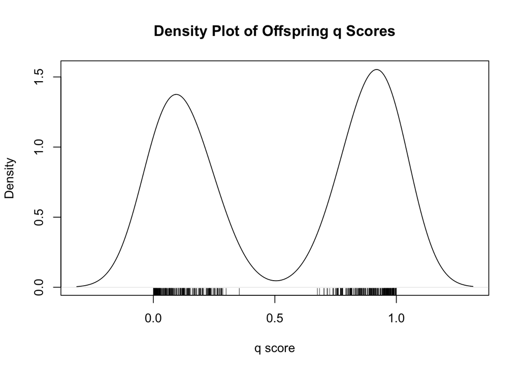

```r
# To plot offspring q scores, take the q scores of the parents from the previous data frame and average them
q_scores_df$averaged_q_scores <- (q_scores_df$sampled_q_maternal + q_scores_df$sampled_q_paternal) / 2


# Plot the density plot which shows offspring q scores based on extreme phenotype assortative mating
plot(density(q_scores_df$averaged_q_scores),
     main = "Density Plot of Offspring q Scores",
     xlab = "q score",
     ylab = "Density")

# Add a rug plot to the bottom of the density plot to show the individual data points that make up the distribution
rug(q_scores_df$averaged_q_scores)
```

```r
# Perform Spearman rank correlation test between maternal and paternal q scores
cor_test_result <- cor.test(q_scores_df$sampled_q_maternal,
                           q_scores_df$sampled_q_paternal,
                           method = "spearman")
# Print the correlation test result
print(cor_test_result)
```

```
##
##  Spearman's rank correlation rho
##
## data:  q_scores_df$sampled_q_maternal and q_scores_df$sampled_q_paternal
## S = 5531214, p-value < 2.2e-16
## alternative hypothesis: true rho is not equal to 0
## sample estimates:
##       rho
## 0.7345007
```